# The Natural History of Clonal Haematopoiesis

Historical growth and its determinants; poor fits and their determinants

José Guilherme de Almeida

Moritz Gerstung

# 1 Historical growth effect

We here define historical growth effect as the growth effect calculated only from posterior samples which yield age at onset estimates which are larger than 0.

```r
pop_size <- 0.5e5
source("Scripts/vaf_dynamics_functions.R")
```

[output not shown]

[output not shown]

[output not shown]

[output not shown]

[output not shown]

[output not shown]

[output not shown]

```r
source("Scripts/prepare_data.R")
model_file_name <- "models/model_ch.RDS"
dir.create("figures/model_ch/other_associations")
set.seed(42)
model_id <- "model_ch"
load(file = sprintf('data_output/vaf_modelling_coefficients_%s.Rdata',model_id))
values_model <- readRDS(file = model_file_name)

site_samples <- values_model$draws$`11`[,grep('site',colnames(values_model$draws$`11`))]
gene_samples <- values_model$draws$`11`[,grep('gene',colnames(values_model$draws$`11`))]
clone_samples <- values_model$draws$`11`[,grep('clone',colnames(values_model$draws$`11`))]
offset_samples <- values_model$draws$`11`[,grep('u',colnames(values_model$draws$`11`))]
beta_samples <- values_model$draws$`11`[,grep('beta',colnames(values_model$draws$`11`))] %>%
  unlist()

sampling_idxs <- r_values_full %>%
  subset(b_site_095 + b_gene_095 + b_clone_095 > 0) %>%
  group_by(
    individual,site,
    site_numeric,
    gene_numeric,
    clone_numeric
  ) %>%
  summarise(
    minAge = min(age[which(round(true/coverage,4) >= 0.005)]),
    maxAge = max(age),
    maxVAF = max(true/coverage)
  ) %>%
  arrange(site)

c_names <- colnames(values_model$draws$`11`)

good_sites_individual <- statistics_data %>%
  ungroup %>%
  select(site,individual,sum_stat) %>%
  filter(sum_stat) %>%
  select(-sum_stat)
```

```r
historical_estimates <- sampling_idxs %>%
  apply(1,function(x) {
    site_numeric <- as.numeric(x[3])
    gene_numeric <- as.numeric(x[4])
    clone_numeric <- as.numeric(x[5])
    minAge <- as.numeric(x[6])

    if (is.na(site_numeric)) {
      b_site <- 0} else {
        b_site <- site_samples[,site_numeric]
      }
    b_gene <- gene_samples[,gene_numeric]
    b_clone <- clone_samples[,clone_numeric]
    b <- b_gene + b_clone + b_site
    u_values <- offset_samples[,clone_numeric]
    ages_at_onset <- t0_adjusted(u_values,b,g=2,n=pop_size) + values_model$min_age
    biologically_feasible <- ages_at_onset > 0 & ages_at_onset < minAge
    historical_b <- b[biologically_feasible]
    Q <- quantile(historical_b,c(0.05,0.5,0.95),na.rm = T)
    Q_observed <- quantile(b,c(0.05,0.5,0.95),na.rm = T)
    names(Q) <- c("Q05","Q50","Q95")
    return(data.frame(individual=x[1],
                      site=x[2],
                      observed_growth_q05=Q_observed[1],
                      observed_growth_q50=Q_observed[2],
                      observed_growth_q95=Q_observed[3],
                      observed_growth_mean=mean(b,na.rm=T),
                      historical_growth_q05=Q[1],
                      historical_growth_q50=Q[2],
                      historical_growth_q95=Q[3],
                      historical_growth_mean=mean(historical_b,na.rm=T),
                      min_age=minAge))
  }) %>%
  do.call(what=rbind)
historical_estimates$gene <- str_match(historical_estimates$site,"[A-Z0-9]+")
historical_estimates <- historical_estimates %>%
  filter(paste(individual,site) %in% paste(good_sites_individual$individual,good_sites_individual$site))
```

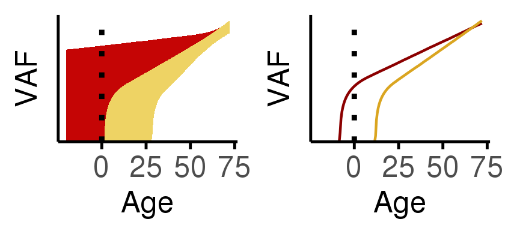

```r
idxs <- sampling_idxs %>%
  subset(individual == 4088 & site == "DNMT3At-E578X")

S <- data.frame(
  u = offset_samples[,idxs$clone_numeric],
  b_gene = gene_samples[,idxs$gene_numeric],
  b_site = site_samples[,idxs$site_numeric],
  b_clone = clone_samples[,idxs$clone_numeric],
  idx = seq(1,nrow(clone_samples)),
  maxAge = idxs$maxAge) %>%
  apply(1,function(x) {
    u <- as.numeric(x[1])
    b_gene <- as.numeric(x[2])
    b_site <- as.numeric(x[3])
    b_site <- ifelse(is.na(b_site),0,b_site)
    b_clone <- as.numeric(x[4])
    max_age <- as.numeric(x[6])
    b <- b_gene+b_site+b_clone
    traj <- suppressWarnings(trajectory_from_parameters_2(
      b = b,u = u,g = 2,N = pop_size,x = seq(-20,max_age,by = 0.5) - values_model$min_age))
    age_at_onset <- t0_adjusted(u,b,g = 2,n = pop_size)
    return(data.frame(
      age = traj$x + values_model$min_age,
      VAF = traj$y,
      t0 = age_at_onset + values_model$min_age,
      ID = as.numeric(x[5])
    ))
  }) %>%
  do.call(what = rbind) %>%
  mutate(plausible = t0 >= 0) %>%
  mutate(VAF = ifelse(is.na(VAF),0,VAF))

x <- rbind(
  S %>%
    subset(plausible == T) %>%
    group_by(age,plausible) %>%
    summarise(q05 = quantile(VAF,0.05,na.rm = T),
              q50 = quantile(VAF,0.5,na.rm = T),
              q95 = quantile(VAF,0.95,na.rm = T)) %>%
    as.data.frame,
  S %>%
    group_by(age) %>%
    summarise(plausible = as.logical(0),
              q05 = quantile(VAF,0.05,na.rm = T),
              q50 = quantile(VAF,0.5,na.rm = T),
              q95 = quantile(VAF,0.95,na.rm = T)) %>%
    as.data.frame) %>%
  subset(q95 > 0)
plot_good_bad <- x %>%
  group_by(age) %>%
  subset(q95 > 0) %>%
  mutate(q05 = ifelse(
    all(c(T,F) %in% plausible),
    ifelse(plausible == F,min(q95),q05),
    q05)) %>%
  ggplot(aes(x = age,ymin = q05,ymax = q95,fill = plausible)) +
  geom_ribbon() +
  geom_vline(xintercept = 0,linetype = 3,
             size = 0.5) +
  theme_gerstung(base_size = 6) +
  xlab("Age") +
  ylab("VAF") +
  theme(axis.text.y = element_blank(),
        axis.ticks.y = element_blank()) +
  scale_fill_manual(values = colorspace::lighten(c("red4","goldenrod"),amount = 0.01),
                    guide = F) +
  scale_y_continuous(trans = 'log10') +
  scale_x_continuous(breaks = c(0,25,50,75))

plot_plausible <- x %>%
  ggplot(aes(x = age,y = q50,group = plausible,colour = plausible)) +
  geom_line(size = 0.25) +
  geom_vline(xintercept = 0,linetype = 3,
             size = 0.5) +
  theme_gerstung(base_size = 6) +
  xlab("Age") +
  ylab("VAF") +
  theme(axis.text.y = element_blank(),
        axis.ticks.y = element_blank()) +
  scale_colour_manual(values = c("red4","goldenrod"),guide = F) +
  scale_y_continuous(trans = 'log10') +
  scale_x_continuous(breaks = c(0,25,50,75),limits = c(min(x$age),max(x$age)))

plot_grid(plot_good_bad,plot_plausible) +
  ggsave(filename = sprintf("figures/%s/dynamic_coefficients/good_bad_traj.pdf",model_id),
         width = 1.4,height = 0.65)
```

## 1.1 Comparing historical with observed growth

We can see clearly a bias in terms of genes where the difference between historical and observed growth is concerned - particularly, the phase of clonal dynamics we are able to observe for *TP53*, *DNMT3A* and *BRCC3* is far too slow to explain the observed VAF.

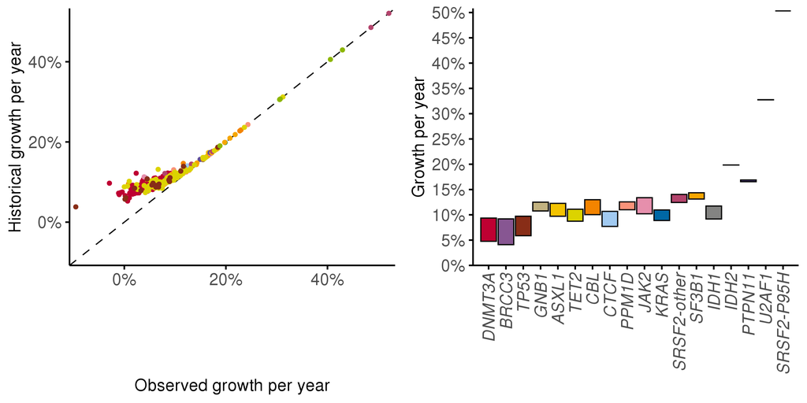

```r
aging_order <- c(
  "DNMT3A","BRCC3","TP53","GNB1","ASXL1","TET2","CBL",
  "CTCF","PPM1D","JAK2","KRAS","SRSF2-other","SF3B1","IDH1",
  "IDH2","PTPN11","U2AF1","SRSF2-P95H")
min_max <- c(
  exp(min(historical_estimates$observed_growth_mean,historical_estimates$historical_growth_mean,na.rm=T))-1,
  exp(max(historical_estimates$observed_growth_mean,historical_estimates$historical_growth_mean,na.rm=T))-1
)

growth_per_year_plot <- historical_estimates %>%
  ggplot(aes(x = exp(observed_growth_mean)-1,
             y = exp(historical_growth_mean)-1,
             colour = gene)) +
  geom_abline(slope = 1,
              size = 0.2,
              linetype=2) +
  geom_point(size = 0.2) +
  scale_y_continuous(limits = min_max,
                     breaks = seq(-0.2,1,by = 0.2),
                     expand = c(0.02,0),
                     labels = sprintf("%s%%",seq(-0.2,1,by = 0.2)*100)) +
  scale_x_continuous(limits = min_max,
                     breaks = seq(-0.2,1,by = 0.2),
                     expand = c(0.02,0),
                     labels = sprintf("%s%%",seq(-0.2,1,by = 0.2)*100)) +
  theme_gerstung(base_size = 6) +
  scale_colour_manual(values = gene_colours,guide = F) +
  xlab("Observed growth per year") +
  ylab("Historical growth per year")

growth_per_year_gene_plot <- historical_estimates %>%
  mutate(gene = ifelse(gene == "SRSF2",
                       ifelse(site == "SRSF2-P95H",
                              "SRSF2-P95H",
                              "SRSF2-other"),
                       gene)) %>%
  group_by(gene) %>%
  summarise(average_historical_growth = mean(exp(historical_growth_mean)-1,na.rm=T),
            average_observed_growth = mean(exp(observed_growth_mean)-1,na.rm=T)) %>%
  ggplot(aes(x = factor(gene,levels = aging_order),
             y = (average_observed_growth + average_historical_growth)/2,
             width = 0.9,
             height = average_historical_growth-average_observed_growth,
             fill = str_match(gene,"[A-Z0-9]+"))) +
  geom_tile(size = 0.2,color = "black") +
  geom_hline(yintercept = 0,size = 0.2) +
  theme_gerstung(base_size = 6) +
  xlab("") +
  ylab("Growth per year") +
  scale_y_continuous(breaks = seq(-0.2,1,by = 0.05),
                     labels = sprintf("%s%%",seq(-0.2,1,by = 0.05)*100),
                     expand = c(0,0,0.01,0)) +
  scale_x_discrete(expand = c(0.05,0.05)) +
  scale_fill_manual(values = gene_colours,
                    guide = F) +
  rotate_x_text(face = "italic")

plot_grid(growth_per_year_plot,growth_per_year_gene_plot,nrow=1,align = "h") +
  ggsave(filename = sprintf("figures/%s/dynamic_coefficients/historical_growth_figure.pdf",model_id),
         height = 2,
         width = 4,
         useDingbats = F)
```

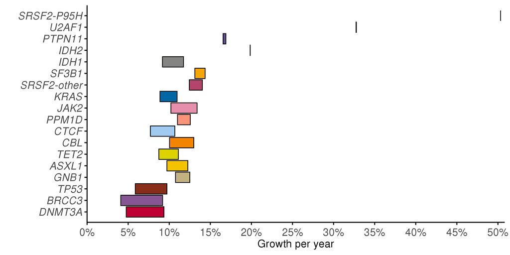

```r
growth_per_year_gene_plot +
  theme(axis.text.x = element_text(face = "plain",angle = 0,hjust = 0.5),
        axis.text.y = element_text(face = "italic")) +
  coord_flip() +
  ggsave(filename = sprintf("figures/%s/dynamic_coefficients/historical_growth_figure_larger.pdf",model_id),
         width = 3.2,height = 2.3)
```

## 1.2 Investigating the determinants of the difference between historical and observed growth effect

```r
unique_genes <- historical_estimates %>%
  group_by(gene) %>%
  filter(length(unique(paste(individual,site))) > 10) %>%
  select(gene) %>%
  distinct %>%
  unlist
historical_estimates <- historical_estimates %>%
  mutate(
    ratio_q05 = exp(historical_growth_q05-observed_growth_q05),
    ratio_q50 = exp(historical_growth_q50-observed_growth_q50),
    ratio_q95 = exp(historical_growth_q95-observed_growth_q95),
    ratio_mean = exp(historical_growth_mean-observed_growth_mean)
  )
```

### 1.2.1 Distribution by gene

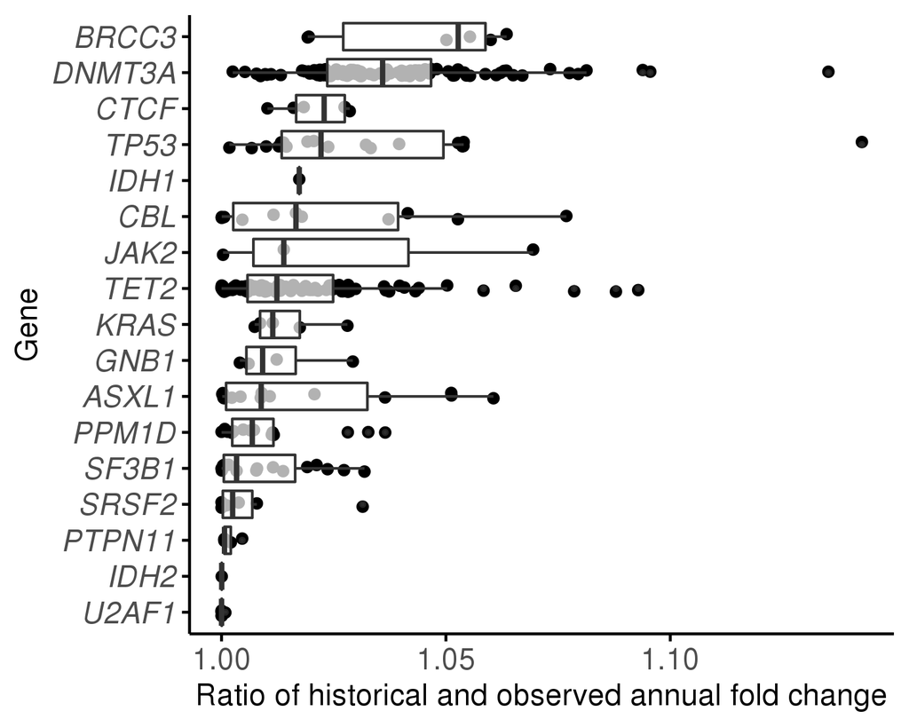

```r
historical_estimates %>%
  group_by(gene) %>%
  mutate(M = unlist(quantile(ratio_q50,c(0.5),na.rm = T))) %>%
  ggplot(aes(x = reorder(gene,M),y = ratio_q50)) +
  geom_point(size = 0.5,position = position_jitter(width = 0.1)) +
  geom_boxplot(outlier.size = 0,alpha = 0.7,size = 0.25) +
  coord_flip() +
  theme_gerstung(base_size = 6) +
  theme(axis.text.y = element_text(face = "italic")) +
  ylab("Ratio of historical and observed annual fold change") +
  xlab("Gene")
```

### 1.2.2 Association with recurrence and truncation status

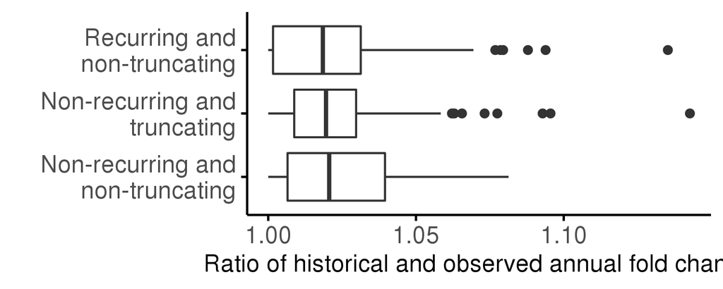

```r
unique_site_multiple <- values_model$sub_data %>%
  select(amino_acid_change,site_numeric_multiple) %>%
  subset(!is.na(site_numeric_multiple)) %>%
  distinct %>%
  arrange(site_numeric_multiple) %>%
  select(amino_acid_change) %>%
  unlist %>%
  as.character() %>% as.factor

tmp <- historical_estimates %>%
  mutate(truncating = grepl("[A-Z0-9]+t-",site)) %>%
  mutate(recurring = site %in% unique_site_multiple) %>%
  mutate(f = paste(
    ifelse(recurring,"Recurring","Non-recurring"),
    ifelse(truncating,"truncating","non-truncating"),
    sep = ' and\n'
  ))

anvar_test <- anova(glm(ratio_q50 ~ f,data = tmp),
                    test = "F")
tmp %>%
  ggplot(aes(x = f,y = ratio_q50)) +
  geom_boxplot(outlier.size = 0.5,size = 0.25) +
  ylab("Ratio of historical and observed annual fold change") +
  xlab("") +
  theme_gerstung(base_size = 6) +
  coord_flip() +
  scale_y_continuous() +
  ggsave(useDingbats=FALSE,sprintf("figures/%s/other_associations/uc_tnt_rec.pdf",model_id),
         height = 1.2,width = 2.0)
```

```r
anvar_test
```

|  | Df | Deviance | Resid. Df | Resid. Dev | F | Pr(>F) |
| --- | --- | --- | --- | --- | --- | --- |
| NULL | NA | NA | 309 | 0.1591604 | NA | NA |
| f | 2 | 4.337146e-05 | 307 | 0.1591170 | 0.0418404 | 0.9590283 |

### 1.2.3 Association with gender and smoking

We tested whether age, gender and smoking could explain a greater amount of variance than age alone and found no evidence for this.

```r
smoking_gender_data <- load_smoking_data() %>%
  group_by(SardID) %>%
  summarise(HasSmoked = any(PackYears>0)) %>%
  merge(distinct(select(full_data,SardID,Gender))) %>%
  select(individual = SardID,HasSmoked,Gender)

historical_estimates_gender_smoking <- merge(
  historical_estimates,smoking_gender_data,
  by = c("individual"))

tmp <- historical_estimates_gender_smoking %>%
  filter(!is.na(ratio_q50) & !is.na(HasSmoked) & !is.na(Gender) & !is.na(min_age))
all_models <- list(
  `All genes` = list(
    m = glm(ratio_q50 ~ HasSmoked + Gender + min_age,data = tmp,
            family = Gamma),
    null_m = glm(ratio_q50 ~ min_age,data = tmp,
                 family = Gamma)))

for (g in unique_genes) {
  x <- tmp %>%
    subset(gene == g)
  all_models[[g]] <- list(
    m = glm(ratio_q50 ~ HasSmoked + Gender + min_age,data = x,
            family = Gamma),
    null_m = glm(ratio_q50 ~ min_age,data = x,
                 family = Gamma))
}

significance_df <- all_models %>%
  lapply(
    function(x) anova(x$null_m,x$m,test="F")[2,c(5,6)]
  ) %>%
  do.call(what = rbind)
significance_df$gene <- names(all_models)
significance_df$SignificantAfterCorrection <- p.adjust(significance_df$`Pr(>F)`,method = "BH") < 0.05

significance_df
```

|  | F | Pr(>F) | gene | SignificantAfterCorrection |
| --- | --- | --- | --- | --- |
| All genes | 0.3979083 | 0.6720741 | All genes | FALSE |
| ASXL1 | 0.3824677 | 0.6917399 | ASXL1 | FALSE |
| CBL | 1.4374314 | 0.2999055 | CBL | FALSE |
| DNMT3A | 1.9326429 | 0.1507258 | DNMT3A | FALSE |
| PPM1D | 0.7568028 | 0.4942461 | PPM1D | FALSE |
| SF3B1 | 2.1738457 | 0.1482401 | SF3B1 | FALSE |
| TET2 | 1.1048030 | 0.3356779 | TET2 | FALSE |
| TP53 | 2.4339698 | 0.1238297 | TP53 | FALSE |

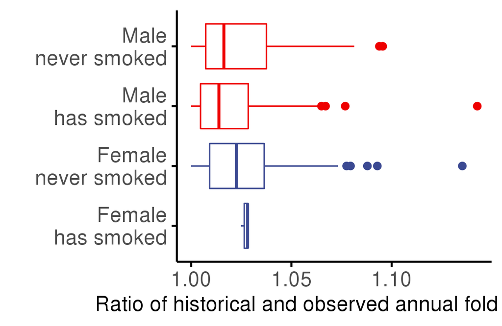

```r
tmp %>%
  mutate(
    L = paste(ifelse(Gender == "M","Male","Female"),
              ifelse(HasSmoked == T,"\nhas smoked","\nnever smoked"),
              sep = '')
  ) %>%
  ggplot(aes(x = L,y = ratio_q50, colour = Gender)) +
  geom_boxplot(size = 0.2,outlier.size = 0.5) +
  theme_gerstung(base_size = 6) +
  coord_flip() +
  xlab("") +
  ylab("Ratio of historical and observed annual fold change") +
  scale_y_continuous() +
  scale_colour_aaas(guide = F)
```

### 1.2.4 Associations with blood indices

Here, we test the association between blood indices and the historical/observed fold change ratio. We study only a few relevant blood indices - haemoglobin concentration (Hb), mean corpuscular volume (MCV), red cell distribution width (RDW), white blood cell count (WBC), neutrophyle, lymphocyte and monocyte absolute counts (Neut, Lymph and Mono, respectively), and platelet counts (Plt). To characterise these blood indices over time, we calculate their average value (Mean) and their dynamics assuming they follow a linear trend through time (Slope).

```r
stat_sign_individuals <- statistics_data %>%
  group_by(individual,site) %>%
  summarise(sig = sum(sum_stat == T) > 0)

blood_count_data <- load_blood_count_data()
fuller_data <- merge(load_data_keep(),blood_count_data,by = c("SardID","Phase"),all.y = T) %>%
  subset(!(SardID %in% c(load_excluded_individuals(),load_excluded_individuals_lymph())))

complete_blood_counts <- fuller_data %>%
  group_by(SardID) %>%
  mutate(relative_timepoint = Phase - min(Phase) + 1) %>%
  transmute(
    Phase,Age,relative_timepoint,Gender,
    HB,
    MCV,
    RDW,
    WBC,
    NEUT = NEUT_PERC*WBC,
    LYMPH = LYMPH_PERC*WBC,
    MONO = MONO_PERC*WBC,
    PLT,
    Phase,Age,
    VAF) %>%
  distinct %>%
  gather(key = "par",value = "val",-SardID,-Phase,-Age,-relative_timepoint,-Gender,-VAF)

blood_counts_effects <- complete_blood_counts %>%
  select(-VAF)

id_par_df <- blood_counts_effects %>%
  select(SardID,par) %>%
  distinct

max_vaf <- full_data %>%
  group_by(SardID,amino_acid_change) %>%
  summarise(
    maxVAF = VAF[which.max(Age)]) %>%
  transmute(maxVAF = maxVAF,
            SardID = SardID,
            site = amino_acid_change)

pre_slope_intercept_blood <- id_par_df %>%
  apply(1,function(x) {
    S <- gsub(' ','',x[1])
    P <- x[2]
    sub_data <- blood_counts_effects %>%
      subset(SardID == S & par == P) %>%
      distinct %>%
      subset(!is.na(Age))
    age_val <- sub_data %>%
      ungroup() %>%
      select(Age,val) %>%
      na.omit() %>%
      distinct
    Age <- age_val$Age
    val <- age_val$val
    Formula <- 'Age ~ val'

    M <- data.frame(
      SardID = S,
      Slope = ifelse(
        length(Age) > 1,
        sum((Age - mean(Age))*(val - mean(val))) / sum((Age-mean(Age))^2),
        NA),
      par = P,
      meanAge = mean(Age),
      Mean = mean(val),
      Gender = sub_data$Gender[1]
    )
    return(M)
  }) %>%
  Filter(f = function(x) !is.null(x)) %>%
  do.call(what = rbind) %>%
  mutate(
    par = factor(
      par,
      levels = c("MCV","HB","RDW",
                 "PLT",
                 "WBC","LYMPH","MONO","NEUT"),
      labels = c("MCV","Hb","RDW",
                 "Plt",
                 "WBC","Lymph","Mono","Neut")
    )
  )

slope_intercept_blood_full_ <- pre_slope_intercept_blood %>%
  merge(select(max_vaf,-maxVAF),by = c("SardID"),all.x = T) %>%
  merge(select(historical_estimates,SardID = individual,site,gene,ratio_q50),
        by = c("SardID","site"),all.x = T) %>%
  merge(stat_sign_individuals,by.x = c("SardID","site"),by.y = c("individual","site"))

slope_intercept_blood_full <- slope_intercept_blood_full_ %>%
  subset(sig == T)
```

#### 1.2.4.1 *DNMT3A*

```r
bh_threshold <- function(p.val,fdr=0.05) {
  n_t <- length(p.val)
  spv <- sort(p.val)
  n_alpha_n <- seq(1,n_t) * (fdr/n_t)
  out <- n_alpha_n[max(which(spv < n_alpha_n))]
  out <- ifelse(is.na(out),min(n_alpha_n),out)
  return(out)
}

tmp <- slope_intercept_blood_full %>%
  subset(gene == "DNMT3A")

all_comparisons_dnmt3a <- list()
for (P in unique(tmp$par)) {
  x <- tmp %>%
    subset(par == P) %>%
    subset(!is.na(Mean) & !is.na(Slope))
  if (P == "RDW") {
    Mm <- glm(ratio_q50 ~ Gender*meanAge + Mean,data = x,family = Gamma(link = "identity"))
    NMm <- glm(ratio_q50 ~ Gender*meanAge,data = x,family = Gamma(link = "identity"))
    all_comparisons_dnmt3a[[P]] <- data.frame(par = P,anova(NMm,Mm,test = "F")[2,c(5,6)],f = "mean")
  }
  else {
    Mm <- glm(ratio_q50 ~ Gender*meanAge + Mean,data = x,family = Gamma(link = "identity"))
    NMm <- glm(ratio_q50 ~ Gender*meanAge,data = x,family = Gamma(link = "identity"))
    all_comparisons_dnmt3a[[P]] <- data.frame(par = P,anova(NMm,Mm,test = "F")[2,c(5,6)],f = "mean")
    Mm <- glm(ratio_q50 ~ Gender*meanAge + Slope,data = x,family = Gamma(link = "identity"))
    NMm <- glm(ratio_q50 ~ Gender*meanAge,data = x,family = Gamma(link = "identity"))
    all_comparisons_dnmt3a[[P]] <- data.frame(par = P,anova(NMm,Mm,test = "F")[2,c(5,6)],f = "slope")
  }
}
```

#### 1.2.4.2 *TET2*

```r
tmp <- slope_intercept_blood_full %>%
  subset(gene == "TET2")

all_comparisons_tet2 <- list()
for (P in unique(tmp$par)) {
  x <- tmp %>%
    subset(par == P) %>%
    subset(!is.na(Mean) & !is.na(Slope))
  if (P == "RDW") {
    Mm <- glm(ratio_q50 ~ Gender*meanAge + Mean,data = x,family = Gamma(link = "identity"))
    NMm <- glm(ratio_q50 ~ Gender*meanAge,data = x,family = Gamma(link = "identity"))
    all_comparisons_tet2[[P]] <- data.frame(par = P,anova(NMm,Mm,test = "F")[2,c(5,6)],f = "mean")
  }
  else {
    Mm <- glm(ratio_q50 ~ Gender*meanAge + Mean,data = x,family = Gamma(link = "identity"))
    NMm <- glm(ratio_q50 ~ Gender*meanAge,data = x,family = Gamma(link = "identity"))
    all_comparisons_tet2[[P]] <- data.frame(par = P,anova(NMm,Mm,test = "F")[2,c(5,6)],f = "mean")
    Mm <- glm(ratio_q50 ~ Gender*meanAge + Slope,data = x,family = Gamma(link = "identity"))
    NMm <- glm(ratio_q50 ~ Gender*meanAge,data = x,family = Gamma(link = "identity"))
    all_comparisons_tet2[[P]] <- data.frame(par = P,anova(NMm,Mm,test = "F")[2,c(5,6)],f = "slope")
  }
}
```

We find that neither mean nor slope can be used to explain a statistically-significantly larger amount of variance than age and gender when analysing the ratio of historical and observed fold change.

```r
all_comparisons <- rbind(
  cbind(do.call(rbind,all_comparisons_dnmt3a),gene = "DNMT3A"),
  cbind(do.call(rbind,all_comparisons_tet2),gene = "TET2")
)

bht <- bh_threshold(all_comparisons$Pr..F.)
```

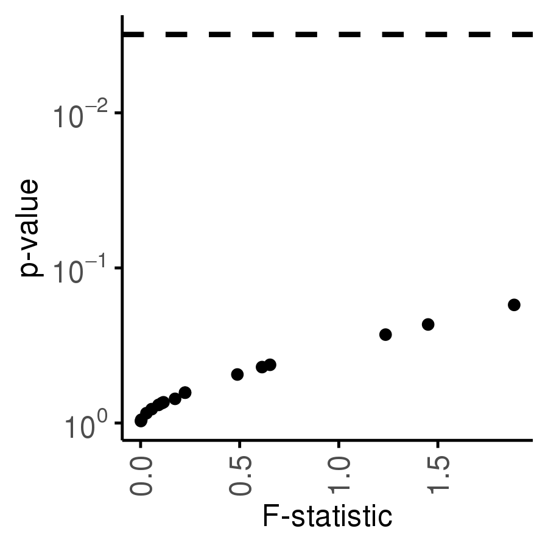

```r
all_comparisons %>%
  ggplot(aes(x = F,y = -log10(`Pr..F.`))) +
  geom_point(size = 0.5) +
  theme_gerstung(base_size = 6) +
  scale_y_continuous(breaks = c(0,1,2,4,6),labels = scientific(c(1,1e-1,1e-2,1e-4,1e-6))) +
  geom_hline(yintercept = -log10(bht),linetype = 2) +
  xlab("F-statistic") +
  ylab("p-value") +
  theme(legend.position = "top",
        legend.margin = margin(),
        legend.key.height = unit(0.1,"cm"),
        axis.text = element_text(size = 6),
        legend.text = element_text(size = 6)) +
  scale_colour_manual(values = gene_colours,
                      name = NULL) +
  scale_shape(name = NULL) +
  rotate_x_text() +
  ggsave(useDingbats=FALSE,
         filename = sprintf("figures/%s/other_associations/blood_count_significance.pdf",model_id),
         width = 3,height = 2)
```

# 2 Poor fits

## 2.1 Investigating the determinants of poor fits

### 2.1.1 Association with recurrence and truncation status

```r
tmp <- statistics_data %>%
  mutate(truncating = grepl("[A-Z0-9]+t-",site)) %>%
  mutate(recurring = site %in% unique_site_multiple) %>%
  mutate(f = paste(
    ifelse(recurring,"Recurring","Non-recurring"),
    ifelse(truncating,"truncating","non-truncating"),
    sep = ' and\n'
  ))

anvar_test <- anova(glm(sum_stat ~ f,data = tmp,family = stats::binomial()),
                    test = "F")
```

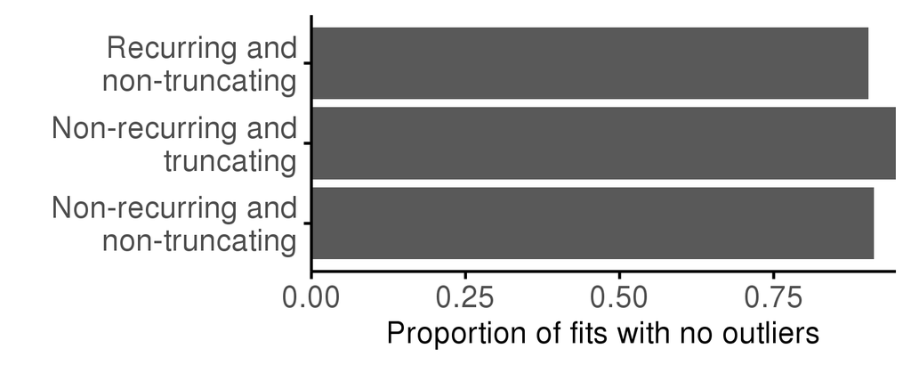

```r
tmp %>%
  group_by(f) %>%
  summarise(Proportion = sum(sum_stat)/length(sum_stat)) %>%
  ggplot(aes(x = f,y = Proportion)) +
  geom_bar(outlier.size = 0.5,size = 0.25,stat = "identity") +
  ylab("Proportion of fits with no outliers") +
  xlab("") +
  theme_gerstung(base_size = 6) +
  coord_flip() +
  scale_y_continuous(expand = c(0,0)) +
  ggsave(useDingbats=FALSE,sprintf("figures/%s/other_associations/uc_tnt_rec.pdf",model_id),
         height = 1.2,width = 2.0)
```

```r
anvar_test
```

|  | Df | Deviance | Resid. Df | Resid. Dev | F | Pr(>F) |
| --- | --- | --- | --- | --- | --- | --- |
| NULL | NA | NA | 684 | 368.0789 | NA | NA |
| f | 2 | 3.564047 | 682 | 364.5149 | 1.782024 | 0.1682972 |

### 2.1.2 Associations with smoking status and gender

```r
good_stat_smoking_gender <- merge(
  statistics_data,smoking_gender_data,
  by = c("individual"))

tmp <- good_stat_smoking_gender %>%
  filter(!is.na(sum_stat) & !is.na(HasSmoked) & !is.na(Gender))
all_models <- list(
  `All genes` = list(
    m = glm(sum_stat ~ HasSmoked + Gender,data = tmp,
            family = stats::binomial()),
    null_m = glm(sum_stat ~ 1,data = tmp,
                 family = stats::binomial())))

for (g in unique_genes) {
  x <- tmp %>%
    subset(gene == g)
  all_models[[g]] <- list(
    m = glm(sum_stat ~ HasSmoked + Gender,data = x,
            family = stats::binomial()),
    null_m = glm(sum_stat ~ 1,data = x,
                 family = stats::binomial()))
}
significance_df <- all_models %>%
  lapply(
    function(x) anova(x$null_m,x$m,test="F")[2,c(5,6)]
  ) %>%
  do.call(what = rbind)
significance_df$gene <- names(all_models)
significance_df$SignificantAfterCorrection <- p.adjust(significance_df$`Pr(>F)`,method = "BH") < 0.05

significance_df
```

|  | F | Pr(>F) | gene | SignificantAfterCorrection |
| --- | --- | --- | --- | --- |
| All genes | 0.3088700 | 0.7342762 | All genes | FALSE |
| ASXL1 | 1.4348332 | 0.2381551 | ASXL1 | FALSE |
| CBL | 0.6361534 | 0.5293246 | CBL | FALSE |
| DNMT3A | 1.2380999 | 0.2899346 | DNMT3A | FALSE |
| PPM1D | 0.9557388 | 0.3845280 | PPM1D | FALSE |
| SF3B1 | 1.1693136 | 0.3105801 | SF3B1 | FALSE |
| TET2 | 0.7352943 | 0.4793643 | TET2 | FALSE |
| TP53 | 1.6424358 | 0.1935081 | TP53 | FALSE |

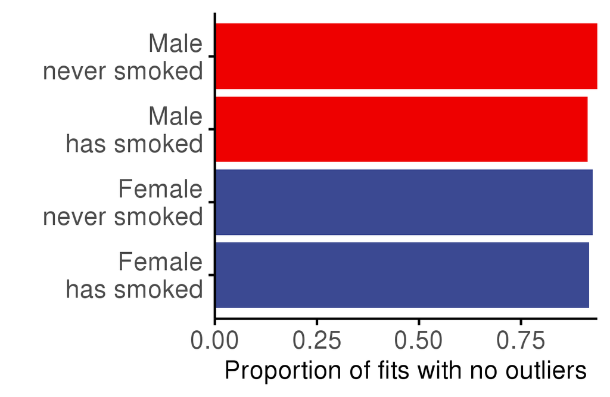

```r
tmp %>%
  mutate(
    L = paste(ifelse(Gender == "M","Male","Female"),
              ifelse(HasSmoked == T,"\nhas smoked","\nnever smoked"),
              sep = '')
  ) %>%
  group_by(L,Gender) %>%
  summarise(proportion = sum(sum_stat) / length(sum_stat)) %>%
  ggplot(aes(x = L,y = proportion, fill = Gender)) +
  geom_bar(stat = "identity") +
  theme_gerstung(base_size = 6) +
  coord_flip() +
  xlab("") +
  ylab("Proportion of fits with no outliers") +
  scale_y_continuous(expand = c(0,0)) +
  scale_fill_aaas(guide = F)
```

### 2.1.3 Association with blood indices

We find no significant associations between a fit having outliers and the blood indices of an individual.

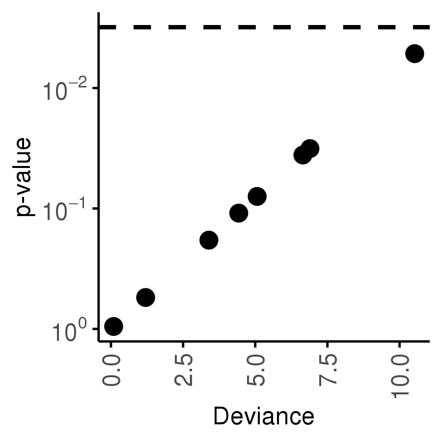

```r
slope_intercept_blood <- slope_intercept_blood_full_ %>%
  group_by(SardID) %>%
  mutate() %>%
  mutate(NTrajectories = length(unique(site)),
         NBadTrajectories = sum(sig == F) / length(unique(par))) %>%
  select(SardID,meanAge,Gender,Mean,Slope,NTrajectories,NBadTrajectories,par) %>%
  distinct %>%
  ungroup()

mt_statistics <- list()
for (P in unique(slope_intercept_blood$par)) {
  tmp <- subset(slope_intercept_blood,par==P) %>%
    na.omit
  NM <- glm(NBadTrajectories ~ NTrajectories + meanAge*Gender,
            data = tmp,family = stats::poisson())
  M <- glm(NBadTrajectories ~ NTrajectories + Slope + Mean + meanAge*Gender,
           data = tmp,family = stats::poisson())
  mt_statistics[[P]] <- list(A=anova(NM,M,test = "Chisq"),P=P)}

mt_statistics %>%
  lapply(function(x) unlist(c(x$P,x$A[2,c(4,5)]))) %>%
  do.call(what = rbind) %>%
  as.data.frame() %>%
  mutate(p.val = as.numeric(as.character(`Pr(>Chi)`)),
         Deviance = as.numeric(as.character(Deviance))) %>%
  ggplot(aes(x = Deviance,y = -log10(p.val))) +
  geom_point() +
  theme_gerstung(base_size = 6) +
  scale_y_continuous(breaks = c(0,1,2,4,6),labels = scientific(c(1,1e-1,1e-2,1e-4,1e-6))) +
  geom_hline(yintercept = -log10(bht),linetype = 2) +
  xlab("Deviance") +
  ylab("p-value") +
  theme(legend.position = "top",
        legend.margin = margin(),
        legend.key.height = unit(0.1,"cm"),
        axis.text = element_text(size = 6),
        legend.text = element_text(size = 6)) +
  scale_colour_manual(values = gene_colours,
                      name = NULL) +
  scale_shape(name = NULL) +
  rotate_x_text() +
  ggsave(useDingbats=FALSE,
         filename = sprintf("figures/%s/other_associations/blood_count_significance.pdf",model_id),
         width = 3,height = 2)
```

# 3 Session details

```r
cat(system("git log -n1", intern=TRUE), sep="\n")
```

```
## commit 4fbf5440593266a49e87221374acd91181583a1e
## Author: josegcpa <josegcpa@ebi.ac.uk>
## Date:   Thu Mar 18 10:37:14 2021 +0000
##
##     fixed a data_output
```

```r
l <- ls()
data.frame(variable=l, Reduce("rbind",lapply(l, function(x) data.frame(classes=paste(class(get(x)),collapse = ','), size=format(object.size(get(x)), units="auto")))))
```

| variable | classes | size |
| --- | --- | --- |
| aging_order | character | 1.2 Kb |
| all_comparisons | data.frame | 4.5 Kb |
| all_comparisons_dnmt3a | list | 17 Kb |
| all_comparisons_tet2 | list | 17 Kb |
| all_models | list | 5.2 Mb |
| and | function | 1 Kb |
| anvar_test | anova,data.frame | 1.9 Kb |
| beta | function | 7.9 Kb |
| beta_samples | mcmc | 176.4 Kb |
| bh_threshold | function | 13.2 Kb |

[output cut: 89 more lines]